# Text analytics & topic modelling on song lyrics

# WORDCLOUD

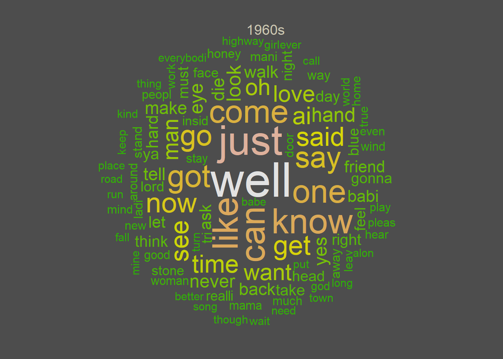

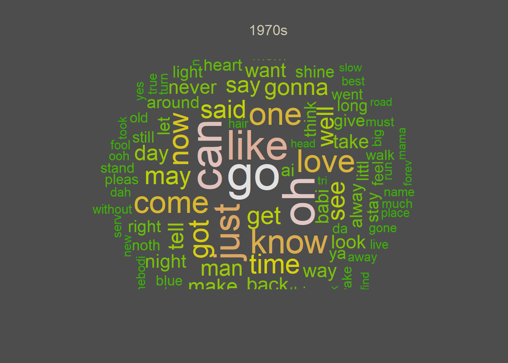

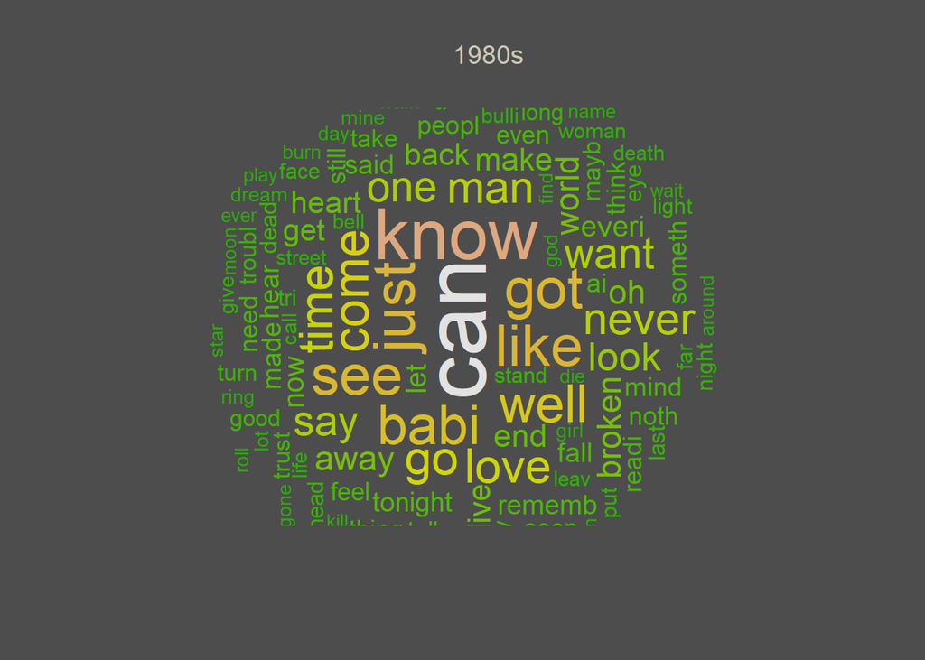

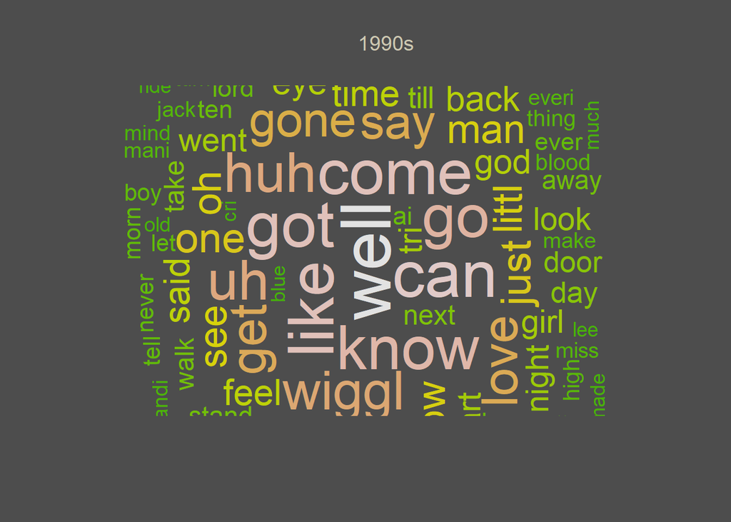

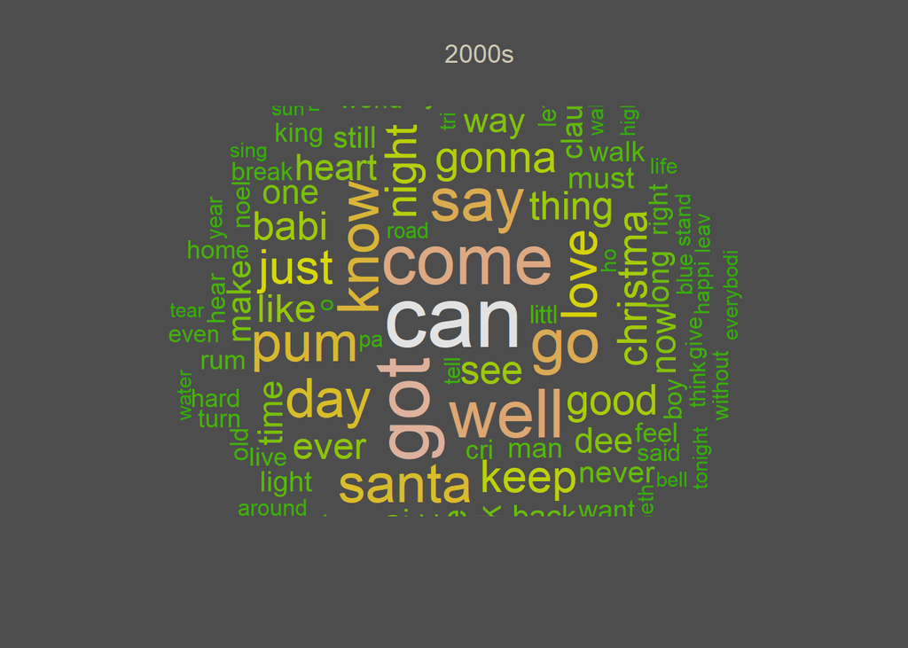

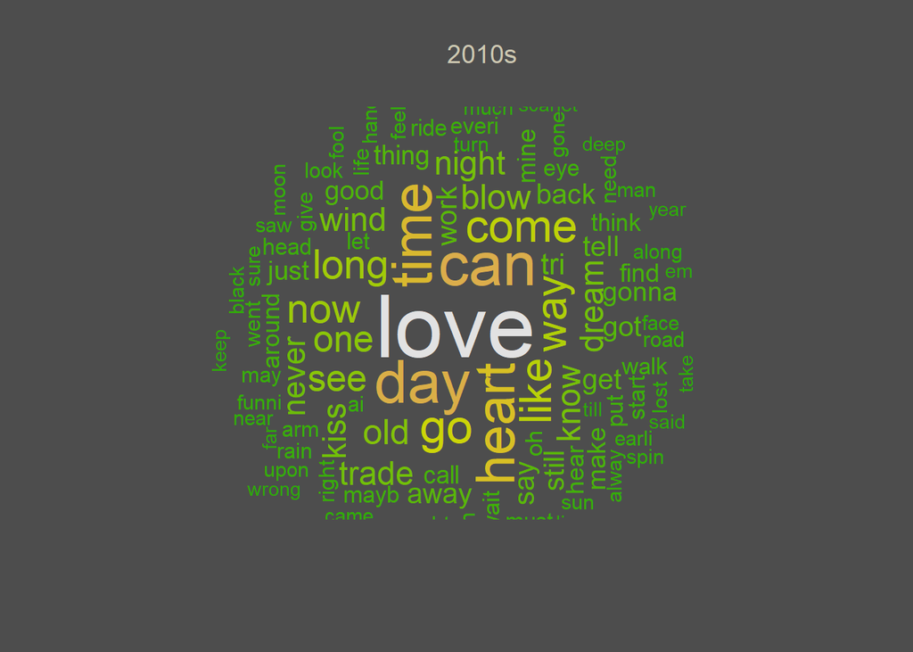

# TOPIC MODELLING

Want to do is to classify documents into topics or themes. Among other things this would help you figure out if there’s anything interest while also directing you to the relevant subsets of the corpus. For small collections, one could do this by simply going through each document but this is clearly unfeasible for corpuses containing thousands of documents.

**Topic modeling** deals with the problem of automatically classifying sets of documents into themes. The algorithm chosen is **Latent Dirichlet Allocation or LDA**, which essentially is a technique that facilitates the automatic discovery of themes in a collection of documents.

The basic assumption behind LDA is that each of the documents in a collection consist of a mixture of collection-wide topics. However, in reality we observe only documents and words, not topics – the latter are part of the hidden (or latent) structure of documents. The aim is to infer the latent topic structure given the words and document. LDA does this by recreating the documents in the corpus by adjusting the relative importance of topics in documents and words in topics iteratively.

```r
# _Build Model ###############################################################

# split into words
by_word <-
  songs %>%
  unnest_tokens(word, lyric)
# find document-word counts
word_counts <-
  by_word %>%
  count(ï..song, word, sort = TRUE) %>%
  ungroup()
# Create document term matrix
songs_dtm <- word_counts %>%
  cast_dtm(ï..song, word, n)
songs_lda <- LDA(songs_dtm, k = 3, control = list(seed = 1234))
# Save for future use
save(songs_lda, file = "Bob_lda_3.RDA")
```

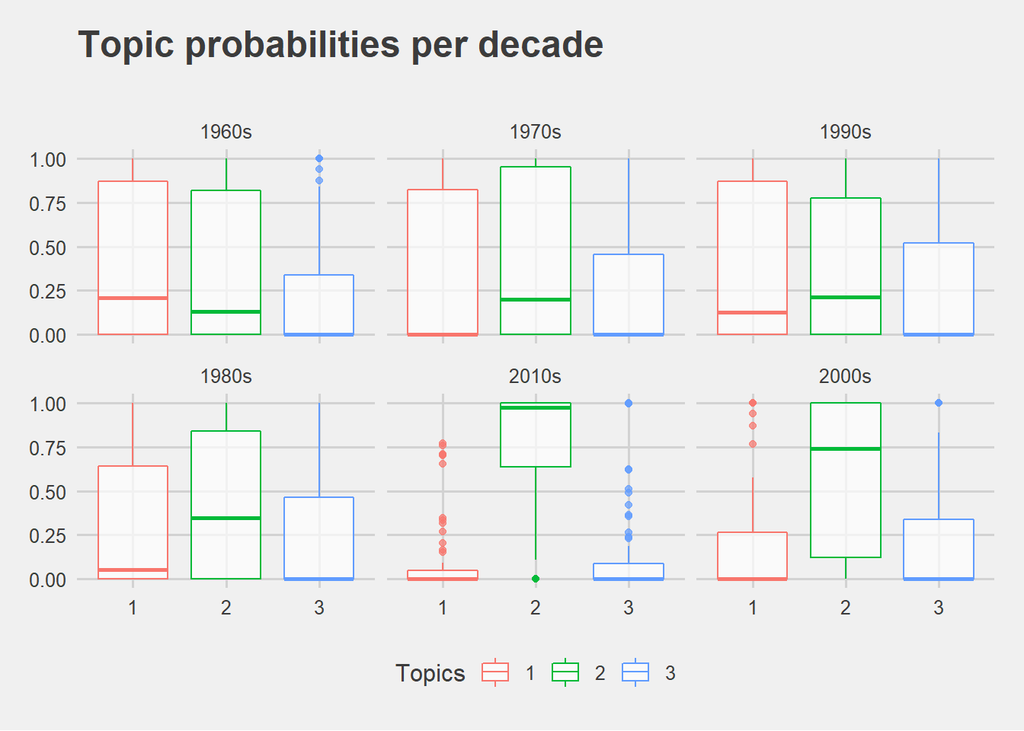

```r
# Load the model
load(file = "Bob_lda_3.RDA")
# _Calculate Tables ##########################################################
library(tidytext)

ap_topics <- tidy(songs_lda, matrix = "gamma")

topics_probs <- right_join(ap_topics, songs[, c("ï..song", "decade")], by = c("document" = "ï..song"))

topics_probs %>%
  mutate(decade = reorder(decade, gamma * topic)) %>%
  ggplot(aes(factor(topic), gamma, colour = factor(topic))) +
  geom_boxplot(alpha = 0.7) +
  labs(y = "Probability", x = "Topic",
       title = "Topic probabilities per decade",
       subtitle = "") +
  theme_fivethirtyeight() +
  labs(col="Topics",
       y = "Probabilities") +
  facet_wrap(~ decade)
```